# Reproducible Research: Peer Assessment 1

### Imputing missing values

Now we need to handle missing values, first of all we should count them:

```r
sum(is.na(DT$steps))
```

```
## [1] 2304
```

In my opinion, the best strategy is to replace all NA with zeros. Why should we invent something?

```r
DT[is.na(DT)] <- 0
```

Lets have a look at how data changed with this, and calculate total number of steps taken each day, as well as median and mean values:

```r
DTdailysumN <- aggregate(list(steps = DT$steps), list(date = DT$date), sum)
mean(DTdailysumN$steps, na.rm = TRUE)
```

```
## [1] 9354.23
```

```r
median(DTdailysumN$steps, na.rm = TRUE)
```

```
## [1] 10395
```

and make a histogram of this new data:

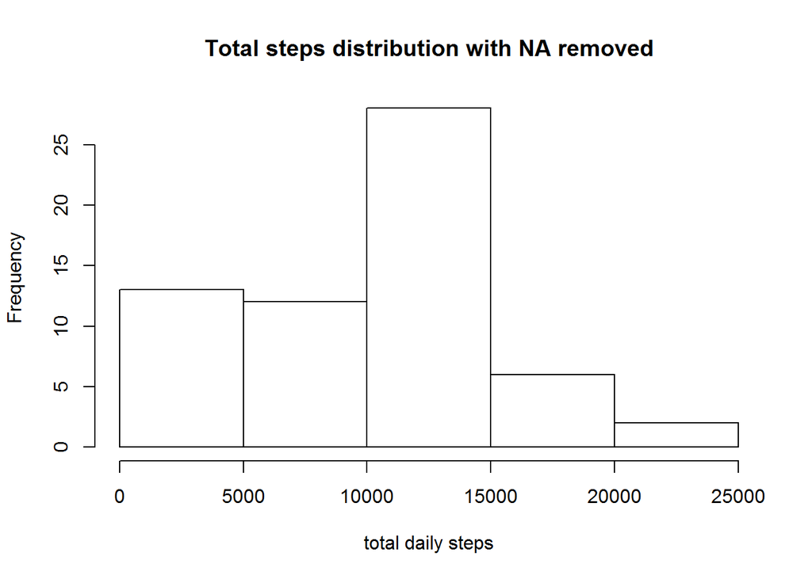

```r
hist(DTdailysumN$steps, xlab ="total daily steps", main = "Total steps distribution with NA removed")
```

As we can see, distribution changed according to addition of zero values.

### Are there differences in activity patterns between weekdays and weekends?

To answer this question we need to introduce new column to the dataset, indicating if the day is weekend of not. Add a column for weekday:

```r
DT$weekday = weekdays(as.Date(DT$date))
```

and another column for weekday type, and convert it into factor:

```r
DT$type <- ifelse(DT$weekday == "Saturday" | DT$weekday == "Sunday", "Weekend", "Weekday")
DT$type <- as.factor(DT$type)
```

To see the differences lets compare daily activity on weekend and on a weekday, but before we need to aggregate data as before taking day type into account:

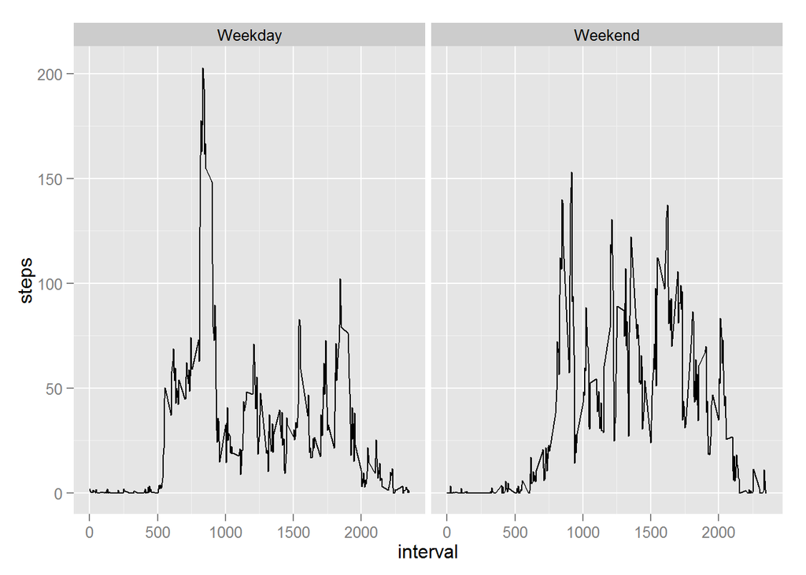

```r
fsteps <-aggregate(data=DT, steps~ type + interval, FUN = mean, na.action = na.omit)
ggplot(data = fsteps, aes(interval, steps )) + geom_line() + facet_grid(.~type)
```

GGplot2 works really well here, and we can clearly see that patterns differ pretty significantly.